# Aprendizado Estatístico

31/01/2018

## O que é aprendizado estatístico?

## Tipos de aprendizado

- Supervisionado
- Envolve a construção de um modelo estatístico para prever ou estimar uma resposta de acordo com uma ou mais informações de entrada.
- **Exemplo**: Um estudo estatístico cujo objetivo é estimar a probabilidade de uma transação ser uma fraude e são fornecidos dados relativos a transações passadas bem como se estas foram uma fraude ou não.
- Não Supervisionado
- Existem variáveis de entrada mas não existe uma variável resposta.
- **Exemplo**: Um estudo em que são fornecidas diversas informações sobre os hábitos de compras dos clientes e deseja-se identificar diferentes segmentos.

## Aprendizado Supervisionado

1. Definir o objetivo
2. Definir a variável resposta (\(y\))
3. Definir as covariáveis que ajudam a prever a resposta (\(X\))
4. Coletar dados
5. Ajustar/Treinar o modelo

## Exemplos

1. Árvores de Decisão
2. Regressão Linear
3. Regressão Logística
4. Florestas Aleatórias
5. Redes Neurais

## Exemplos

1. **Árvores de Decisão**
2. **Regressão Linear**
3. **Regressão Logística**
4. Florestas Aleatórias
5. Redes Neurais

## Arvore de decisao

- Os modelos de árvore de decisão como vamos utilizar são implementados de acordo com o livro Classification and Regression Trees de Breiman, Friedman, Olshen e Stone.
- Pacotes utilizados: rpart, rpart.plot alternativas: tree, party

## Arvore de decisao

- Cria regras do tipo se-então para aproximar uma função.

[figure not shown]

## Árvore de decisão

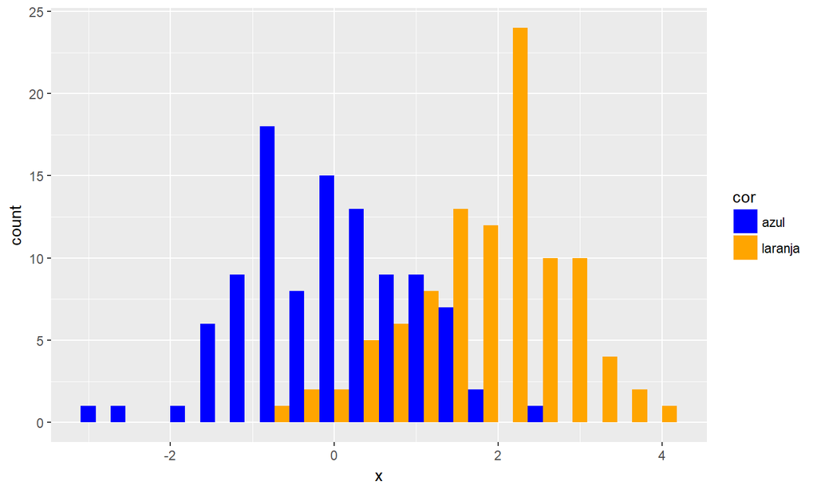

## Exemplo 1:

No R

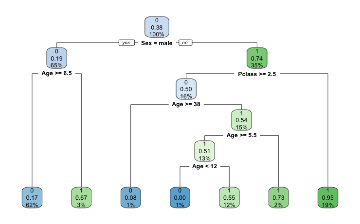

## Aprendizado Supervisionado

1. Definir o objetivo
2. Definir a variável resposta (\(y\))
3. Definir as covariáveis que ajudam a prever a resposta (\(X\))
4. **Ajustar/Treinar o modelo**

## O que é treinar o modelo?

Estimar a função \(f\) nesta equação:

\[y = f(X) + \epsilon\] em que:

- \(y\) é a variável resposta
- \(X\) é uma matriz de covariáveis
- \(\epsilon\) é um componente de aleatoriedade

## Regressão linear

Suposição de que \(f(X)\) é da forma:

\[f(X) = \alpha + \beta X\]

Reduz o problema para: estimar \(\alpha\) e \(\beta\).

## Como estimar \(\alpha\) e \(\beta\)?

\(\alpha\) e \(\beta\) são escolhidos de tal forma que:

\[\sum_{i = 1}^{n} [y_i - (\alpha + \beta x_i)]^2\] seja o menor possível. Isto é, estamos minimizando o *erro quadrático*.

## Exemplo 2:

No R

## Exercício 1:

1. Utilize os dados do data_frame *Cars*
2. Construa um gráfico com as variáveis *speed* vs *dist*
3. Ajuste um modelo de regressão linear simples para tentar prever a variável *dist* através da variável *speed*
4. Reflita sobre o ajuste do modelo.

## Regressão logística

\[=> ln(\frac{p}{1-p}) = f(X) = \alpha + \beta X\] É linear no log da razão de chances => aplicar uma regressão linear usual.

## Regressão logística

Porque?

- Fácil de interpretar: os coeficientes do modelo relacionam-se à chance do evento acontecer
- Retorna a probabilidade de ocorrência do evento avaliado.
- A deriavada é fácil de ser calculada

## Como estimar \(\alpha\) e \(\beta\)?

Os parâmetros são estimados de forma que minimize o erro de classificação:

\[\sum_{i=1}^{n} (y_i - \frac{1}{1 + e^{-f(X_i)}})^2\]

## Exemplo 3:

No R

## Exercício 2:

- carregue os dados dos sobreviventes do titanic
- selecione uma amostra aleatoria que represente 70% de toda a base e guarde os outros 30% em outra tabela.
- Na base de tamanho 70% da original, rode um modelo de regressão logistica tendo como resposta a variável Survived e como variáveis exlpicativas: sexo, Idade e classe.
- Utilize o modelo para predizer os indivíduos da outra base.
- Verifique se o modelo se ajustou bem.

## Overfitting

- Deve ser uma das principais preocupações quando ajustamos um modelo

## O que é overfitting?

O modelo está ajustando variações que são inerentemente aleatórias dos dados.

## Exemplo 4

No R

## Como evitar overfitting?

- Será que o meu modelo está muito complexo?
- Princípio da Navalha de Ocam ou Lei da parcimônia

Na prática:

- Separar a base em 2 partes: treino e teste e avaliar o erro na base de teste
- Outros métodos de avaliação de performance: KS, curva ROC (Regressão Logística)
- Cross-validation

## Cross-Validation

## Agenda

- Instalar 3 pacotes
- Ver vídeo sobre RGB de 30 segundos
- Fazer análise estatística I (onda roxa)
- Fazer análise estatística II (xadrez)
- Fazer análise estatística III (som do captcha para letra)

[Vídeo sobre RGB](https://www.youtube.com/watch?v=CrBFNLvoL6A)

## Cross-Validation

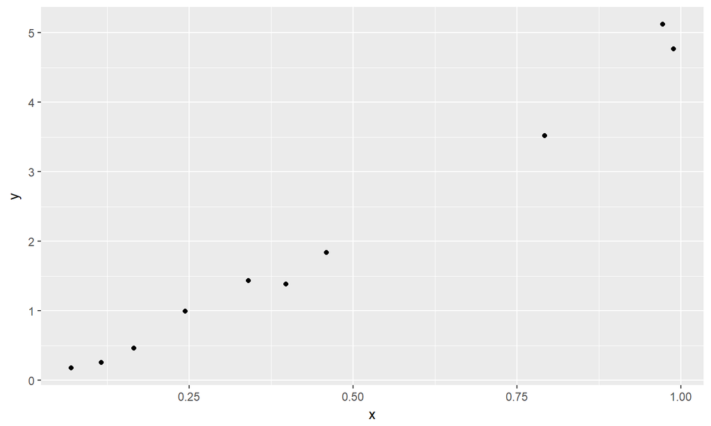

## Cross-Validation

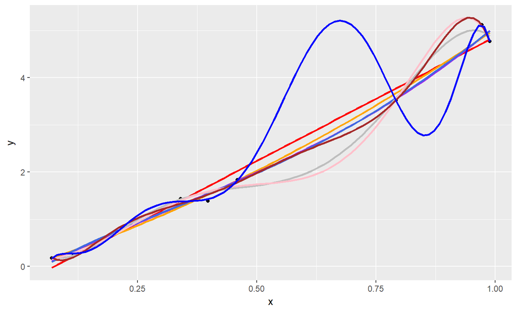

## Cross-Validation

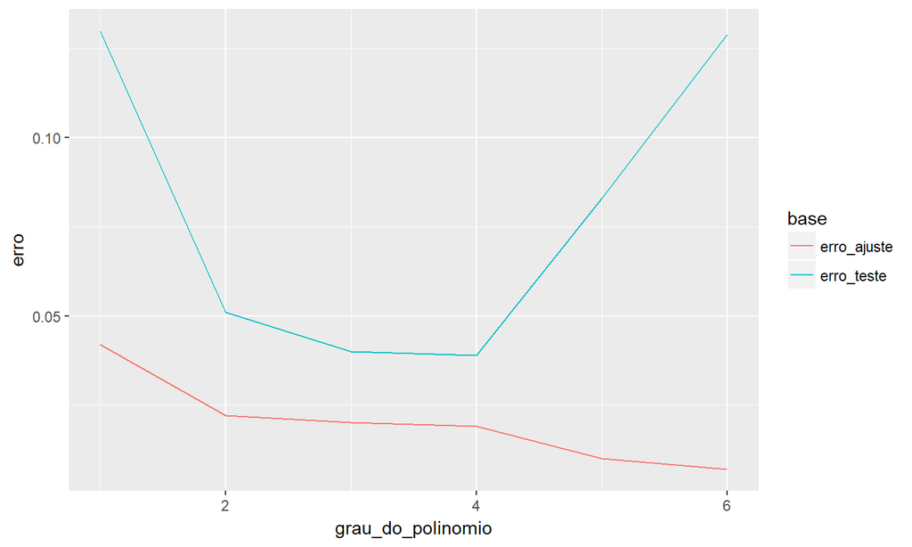